# 1

project 0

introdution to AI

The goal of project is predicting data using python's libraries and working with a dataset.

Project description: Reading data from a csv file and call some pandas function on it and do some analytic work on the data which we had. Then draw some histogram in order to help us understand the data better.Then with the help of PDF and the plots which we draw we can make some prediction about our goal column.

The data which we use is a csv file in same directory.

chapter 1: First with the help of "read_csv" function we read the csv file and put it in a dataframe. Then call functions which was mentioned in part 1. first output is for "tail" function which brings the data from the end of the dataframe and we can pass a value to determine the shown number of datas and the default value is five. second output is for "head" function which is similar to "tail" but it brings datas from start of the dataframe and we pass 1 to it which ends up with first row only. third output gives us information about data such as min, max, mean and etc.

```python
import pandas as pa
import numpy as np
import time
dataframe = pa.read_csv("advertising_dataset.csv")
dataframe.tail()
```

|  | Unnamed: 0 | Daily Time Spent on Site | Age | Area Income | Daily Internet Usage | Ad Topic Line | City | Gender | Country | Timestamp | Clicked on Ad |
| --- | --- | --- | --- | --- | --- | --- | --- | --- | --- | --- | --- |
| 995 | 995 | 72.97 | 30.0 | 71384.57 | 208.58 | Fundamental modular algorithm | Duffystad | Male | Lebanon | 2016-02-11 21:49:00 | 1.0 |
| 996 | 996 | 51.30 | 45.0 | 67782.17 | 134.42 | Grass-roots cohesive monitoring | New Darlene | Male | Bosnia and Herzegovina | 2016-04-22 02:07:01 | 1.0 |
| 997 | 997 | 51.63 | 51.0 | 42415.72 | 120.37 | Expanded intangible solution | South Jessica | Male | Mongolia | 2016-02-01 17:24:57 | 1.0 |
| 998 | 998 | 55.55 | 19.0 | 41920.79 | 187.95 | Proactive bandwidth-monitored policy | West Steven | Female | Guatemala | 2016-03-24 02:35:54 | 0.0 |
| 999 | 999 | NaN | 26.0 | 29875.80 | 178.35 | Virtual 5thgeneration emulation | Ronniemouth | Female | Brazil | 2016-06-03 21:43:21 | 1.0 |

```python
dataframe.head(1)
```

|  | Unnamed: 0 | Daily Time Spent on Site | Age | Area Income | Daily Internet Usage | Ad Topic Line | City | Gender | Country | Timestamp | Clicked on Ad |
| --- | --- | --- | --- | --- | --- | --- | --- | --- | --- | --- | --- |
| 0 | 0 | 68.95 | 35.0 | 61833.9 | 256.09 | Cloned 5thgeneration orchestration | Wrightburgh | Female | Tunisia | 2016-03-27 00:53:11 | 0.0 |

```python
dataframe.describe()
```

|  | Unnamed: 0 | Daily Time Spent on Site | Age | Area Income | Daily Internet Usage | Clicked on Ad |
| --- | --- | --- | --- | --- | --- | --- |
| count | 1000.000000 | 907.000000 | 979.000000 | 1000.000000 | 913.000000 | 832.000000 |
| mean | 499.500000 | 64.794818 | 36.009193 | 55000.000080 | 179.751271 | 0.496394 |
| std | 288.819436 | 15.954841 | 8.783636 | 13414.634022 | 43.957934 | 0.500288 |
| min | 0.000000 | 32.600000 | 19.000000 | 13996.500000 | 104.780000 | 0.000000 |
| 25% | 249.750000 | 50.615000 | 29.000000 | 47031.802500 | 138.550000 | 0.000000 |
| 50% | 499.500000 | 67.940000 | 35.000000 | 57012.300000 | 183.480000 | 0.000000 |
| 75% | 749.250000 | 78.555000 | 42.000000 | 65470.635000 | 217.850000 | 1.000000 |
| max | 999.000000 | 91.430000 | 61.000000 | 79484.800000 | 269.960000 | 1.000000 |

chapter 2: first output is for "info" function which gives us information about number of rows that have data in each column and data type of columns. for label encoding we pass our encode as an dictionary to "replace" funcion which will replace values with our encode and second output is the result.

```python
print("using info function :\n\n")
dataframe.info()
print("\n\n")
dataframe.replace({"Gender" : {"Female" : 0, "Male" : 1}}, inplace = True)
print("dataframe after encoding :\n\n")
dataframe["Gender"]
```

```
using info function :


<class 'pandas.core.frame.DataFrame'>
RangeIndex: 1000 entries, 0 to 999
Data columns (total 11 columns):
 #   Column                    Non-Null Count  Dtype
---  ------                    --------------  -----
 0   Unnamed: 0                1000 non-null   int64
 1   Daily Time Spent on Site  907 non-null    float64
 2   Age                       979 non-null    float64
 3   Area Income               1000 non-null   float64
 4   Daily Internet Usage      913 non-null    float64
 5   Ad Topic Line             1000 non-null   object
 6   City                      1000 non-null   object
 7   Gender                    1000 non-null   object
 8   Country                   1000 non-null   object
 9   Timestamp                 1000 non-null   object
 10  Clicked on Ad             832 non-null    float64
dtypes: float64(5), int64(1), object(5)
memory usage: 86.1+ KB



dataframe after encoding :
```

```
0      0
1      1
2      0
3      1
4      0
      ..
995    1
996    1
997    1
998    0
999    0
Name: Gender, Length: 1000, dtype: int64
```

chapter 3: with help of "isnull" function we get a dataframe which has true for "NaN" values and false for others and by calling "sum" function we can have the number of "NaN" values in each column and first output is the result. we run a loop on column names and fill the missing values with mean of that column with the help of "fillna" function. another method for filling missing datas is filled them a fixed number like 0. when we use fixed number if we run some analysis and algorithm it will use wrong datas and the results will not be so trustable. second output is dataframe filled with mean. third output is datarame filled with 0.

```python
show_null = dataframe.isnull()
show_null.sum()
```

```
Unnamed: 0                    0
Daily Time Spent on Site     93
Age                          21
Area Income                   0
Daily Internet Usage         87
Ad Topic Line                 0
City                          0
Gender                        0
Country                       0
Timestamp                     0
Clicked on Ad               168
dtype: int64
```

```python
df_copy = dataframe.copy()
for col in dataframe.columns:
    if(col != "Clicked on Ad" and pa.api.types.is_numeric_dtype(dataframe[col])):
        dataframe[col].fillna(dataframe[col].mean(), inplace=True)
        df_copy[col].fillna(0, inplace=True)
print("filled with mean :\n\n")
dataframe
```

```
filled with mean :
```

|  | Unnamed: 0 | Daily Time Spent on Site | Age | Area Income | Daily Internet Usage | Ad Topic Line | City | Gender | Country | Timestamp | Clicked on Ad |
| --- | --- | --- | --- | --- | --- | --- | --- | --- | --- | --- | --- |
| 0 | 0 | 68.950000 | 35.0 | 61833.90 | 256.090000 | Cloned 5thgeneration orchestration | Wrightburgh | 0 | Tunisia | 2016-03-27 00:53:11 | 0.0 |
| 1 | 1 | 80.230000 | 31.0 | 68441.85 | 179.751271 | Monitored national standardization | West Jodi | 1 | Nauru | 2016-04-04 01:39:02 | 0.0 |
| 2 | 2 | 69.470000 | 26.0 | 59785.94 | 236.500000 | Organic bottom-line service-desk | Davidton | 0 | San Marino | 2016-03-13 20:35:42 | 0.0 |
| 3 | 3 | 74.150000 | 29.0 | 54806.18 | 245.890000 | Triple-buffered reciprocal time-frame | West Terrifurt | 1 | Italy | 2016-01-10 02:31:19 | 0.0 |
| 4 | 4 | 68.370000 | 35.0 | 73889.99 | 225.580000 | Robust logistical utilization | South Manuel | 0 | Iceland | 2016-06-03 03:36:18 | 0.0 |
| ... | ... | ... | ... | ... | ... | ... | ... | ... | ... | ... | ... |
| 995 | 995 | 72.970000 | 30.0 | 71384.57 | 208.580000 | Fundamental modular algorithm | Duffystad | 1 | Lebanon | 2016-02-11 21:49:00 | 1.0 |
| 996 | 996 | 51.300000 | 45.0 | 67782.17 | 134.420000 | Grass-roots cohesive monitoring | New Darlene | 1 | Bosnia and Herzegovina | 2016-04-22 02:07:01 | 1.0 |
| 997 | 997 | 51.630000 | 51.0 | 42415.72 | 120.370000 | Expanded intangible solution | South Jessica | 1 | Mongolia | 2016-02-01 17:24:57 | 1.0 |
| 998 | 998 | 55.550000 | 19.0 | 41920.79 | 187.950000 | Proactive bandwidth-monitored policy | West Steven | 0 | Guatemala | 2016-03-24 02:35:54 | 0.0 |
| 999 | 999 | 64.794818 | 26.0 | 29875.80 | 178.350000 | Virtual 5thgeneration emulation | Ronniemouth | 0 | Brazil | 2016-06-03 21:43:21 | 1.0 |

1000 rows × 11 columns

```python
print("filled with 0 :\n\n")
df_copy
```

```
filled with 0 :
```

|  | Unnamed: 0 | Daily Time Spent on Site | Age | Area Income | Daily Internet Usage | Ad Topic Line | City | Gender | Country | Timestamp | Clicked on Ad |
| --- | --- | --- | --- | --- | --- | --- | --- | --- | --- | --- | --- |
| 0 | 0 | 68.95 | 35.0 | 61833.90 | 256.09 | Cloned 5thgeneration orchestration | Wrightburgh | 0 | Tunisia | 2016-03-27 00:53:11 | 0.0 |
| 1 | 1 | 80.23 | 31.0 | 68441.85 | 0.00 | Monitored national standardization | West Jodi | 1 | Nauru | 2016-04-04 01:39:02 | 0.0 |
| 2 | 2 | 69.47 | 26.0 | 59785.94 | 236.50 | Organic bottom-line service-desk | Davidton | 0 | San Marino | 2016-03-13 20:35:42 | 0.0 |
| 3 | 3 | 74.15 | 29.0 | 54806.18 | 245.89 | Triple-buffered reciprocal time-frame | West Terrifurt | 1 | Italy | 2016-01-10 02:31:19 | 0.0 |
| 4 | 4 | 68.37 | 35.0 | 73889.99 | 225.58 | Robust logistical utilization | South Manuel | 0 | Iceland | 2016-06-03 03:36:18 | 0.0 |
| ... | ... | ... | ... | ... | ... | ... | ... | ... | ... | ... | ... |
| 995 | 995 | 72.97 | 30.0 | 71384.57 | 208.58 | Fundamental modular algorithm | Duffystad | 1 | Lebanon | 2016-02-11 21:49:00 | 1.0 |
| 996 | 996 | 51.30 | 45.0 | 67782.17 | 134.42 | Grass-roots cohesive monitoring | New Darlene | 1 | Bosnia and Herzegovina | 2016-04-22 02:07:01 | 1.0 |
| 997 | 997 | 51.63 | 51.0 | 42415.72 | 120.37 | Expanded intangible solution | South Jessica | 1 | Mongolia | 2016-02-01 17:24:57 | 1.0 |
| 998 | 998 | 55.55 | 19.0 | 41920.79 | 187.95 | Proactive bandwidth-monitored policy | West Steven | 0 | Guatemala | 2016-03-24 02:35:54 | 0.0 |
| 999 | 999 | 0.00 | 26.0 | 29875.80 | 178.35 | Virtual 5thgeneration emulation | Ronniemouth | 0 | Brazil | 2016-06-03 21:43:21 | 1.0 |

1000 rows × 11 columns

chapter 4: In this part with the help of "value_counts" function we show number of each value in columns. first output is for Gender column (0 for female and 1 for male) second output is for Clicked on Ad column(0 for not clicked and 1 for clicked)

```python
print("Gender value counts :\n\n")
dataframe["Gender"].value_counts()
```

```
Gender value counts :
```

```
0    519
1    481
Name: Gender, dtype: int64
```

```python
print("Clicked on Ad value counts : \n\n")
dataframe["Clicked on Ad"].value_counts()
```

```
Clicked on Ad value counts :
```

```
0.0    419
1.0    413
Name: Clicked on Ad, dtype: int64
```

chapter 5: In this part we put condition on dataframe with "loc" function and number of rows in result dataframe is our answer which we can obtain it with "shape[0]" the output is result for this part number of people with male gender and age more than 20.

```python
rslt_df = dataframe.loc[(dataframe['Age'] > 20) & (dataframe['Gender'] == 1)]
print("number of rows in result :",rslt_df.shape[0])
```

```
number of rows in result : 472
```

chapter 6: Like last part with "loc" function we seperate people who clicked from people who did not click on ad and with "mean" function calculate mean of each dataframe and with "time" library calculate the time of the process. first output is the mean of clicked people. second output is the mean of not clicked people.

```python
tic = time.time()
clicked = dataframe["Age"].loc[dataframe["Clicked on Ad"] == 1].mean()
not_clicked = dataframe["Age"].loc[dataframe["Clicked on Ad"] == 0].mean()
toc = time.time()
print("clicked on Ad avg age :", clicked)
print("not clicked on Ad avg age :", not_clicked)
print("time while using vectorization %f ms " %((toc - tic)))
```

```
clicked on Ad avg age : 40.295599848637366
not clicked on Ad avg age : 31.723325881701896
time while using vectorization 0.001994 ms
```

```python
tic2 = time.time()
sum_clicked = 0
count_clicked = 0
sum_not_clicked = 0
count_not_clicked = 0
for i in range(len(dataframe["Age"])):
    if(dataframe["Clicked on Ad"][i] == 1 ):
        sum_clicked += dataframe["Age"][i]
        count_clicked += 1
    elif(dataframe["Clicked on Ad"][i] == 0 ):
        sum_not_clicked += dataframe["Age"][i]
        count_not_clicked += 1
toc2 = time.time()
print("clicked on Ad avg age :", sum_clicked / count_clicked)
print("not clicked on Ad avg age :", sum_not_clicked / count_not_clicked)
print("time while using loop %f ms " %((toc2 - tic2)))
```

```
clicked on Ad avg age : 40.295599848637366
not clicked on Ad avg age : 31.723325881701896
time while using loop 0.032942 ms
```

chapter 8: with help of "del" we delete non-numeric colmuns and also Gender column and with "hist" function we draw histogram from distribution of data in each numeric column

```
array([[<AxesSubplot:title={'center':'Unnamed: 0'}>,
        <AxesSubplot:title={'center':'Daily Time Spent on Site'}>],
       [<AxesSubplot:title={'center':'Age'}>,
        <AxesSubplot:title={'center':'Area Income'}>],
       [<AxesSubplot:title={'center':'Daily Internet Usage'}>,
        <AxesSubplot:title={'center':'Clicked on Ad'}>]], dtype=object)
```

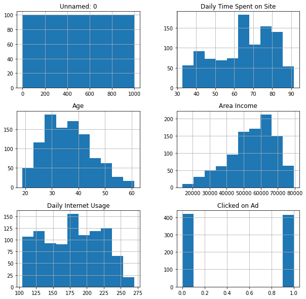

```python
for col in dataframe.columns:
    if(col == "Gender" or not(pa.api.types.is_numeric_dtype(dataframe[col]))):
        del dataframe[col]
dataframe.hist(figsize = (10, 10))
```

chapter 9: with help of "subtract" function we can subtract mean from each cell and with "div" function we can divide them to std and result will be normalized dataframe which is shown in output.

```python
for i in range(len(dataframe.columns)):
    if i != 0:
        col = dataframe.columns[i]
        mean = dataframe[col].mean()
        std = dataframe[col].std()
        dataframe[col] = dataframe[col].subtract(mean).div(std)
dataframe
```

|  | Unnamed: 0 | Daily Time Spent on Site | Age | Area Income | Daily Internet Usage | Clicked on Ad |
| --- | --- | --- | --- | --- | --- | --- |
| 0 | 0 | 0.273474 | -0.116122 | 0.509436 | 1.817578 | -0.992217 |
| 1 | 1 | 1.015870 | -0.576377 | 1.002029 | 0.000000 | -0.992217 |
| 2 | 2 | 0.307698 | -1.151696 | 0.356770 | 1.351152 | -0.992217 |
| 3 | 3 | 0.615713 | -0.806505 | -0.014448 | 1.574722 | -0.992217 |
| 4 | 4 | 0.235301 | -0.116122 | 1.408163 | 1.091154 | -0.992217 |
| ... | ... | ... | ... | ... | ... | ... |
| 995 | 995 | 0.538051 | -0.691441 | 1.221395 | 0.686394 | 1.006632 |
| 996 | 996 | -0.888164 | 1.034517 | 0.952853 | -1.079309 | 1.006632 |
| 997 | 997 | -0.866445 | 1.724900 | -0.938101 | -1.413831 | 1.006632 |
| 998 | 998 | -0.608450 | -1.957144 | -0.974996 | 0.195207 | -0.992217 |
| 999 | 999 | 0.000000 | -1.151696 | -1.872895 | -0.033363 | 1.006632 |

1000 rows × 6 columns

chapter 10: In this part first we calculate mean and std for every column and clicked and not clicked condition then store them in an array called datas; After that we put a interval for x with "linspace" from numpy library then with the help of "scipy.stats" library and function "norm.pdf" we calculate "PDF" for each column and with "plot" function from "matplotlib.pyplot" library we can draw plot for each "PDF" and compare them. After comparing these plots we understand that "Daily Internet Usage" is the best factor for prediction because in the peak of clicked plot it has a meaningful differnce with not clicked plot and vice versa it means that for example if daily internet usage for a person is around "1" you can tell with a good proximity that he/she did not clicked on ad but if it is around "-1" you can tell almost certain that he/she has clicked on ad

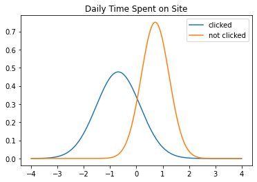

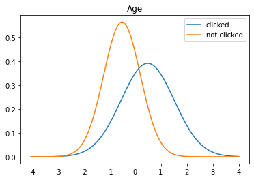

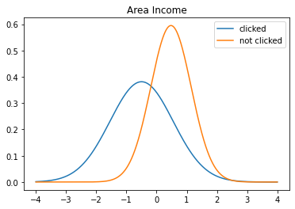

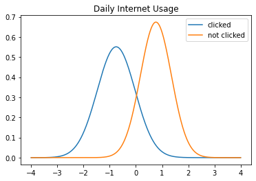

```python
import scipy.stats as ss
import matplotlib.pyplot as plt
datas = []
for i in range(len(dataframe.columns)):
    if i != 0 and i != len(dataframe.columns) - 1:
        col = dataframe.columns[i]
        mean_clicked = dataframe[col].loc[dataframe["Clicked on Ad"] > 0].mean()
        mean_not_clicked = dataframe[col].loc[dataframe["Clicked on Ad"] < 0].mean()
        std_clicked = dataframe[col].loc[dataframe["Clicked on Ad"] > 0].std()
        std_not_clicked = dataframe[col].loc[dataframe["Clicked on Ad"] < 0].std()
        datas.append([col, mean_clicked, mean_not_clicked, std_clicked, std_not_clicked])

x = np.linspace(-4, 4, 5000)
for data in datas:
    y_pdf_clicked = ss.norm.pdf(x, data[1], data[3])
    y_pdf_not_clicked = ss.norm.pdf(x, data[2], data[4])
    plt.plot(x, y_pdf_clicked, label="clicked")
    plt.plot(x, y_pdf_not_clicked, label="not clicked")
    plt.legend()
    plt.title(data[0])
    plt.show()
```

chapter 11: First we seperate those rows which has NaN value in Clicked on Ad column. In the last part we choose Daily Internet Usage as our factor so we calculate pdf for clicked and not clicked condition for every person(passed as x value) if clicked pdf was higher we predict that person clicked on the ad and if not clicked pdf was higher we predict that person did not click on the ad and finally we put the result in csv file called "result.csv" with the help "to_csv" function.

```python
dataframe = dataframe[dataframe["Clicked on Ad"].isnull()]
daily_internet_usage = datas[3]
for i in dataframe[dataframe.columns[0]]:
    y_pdf_clicked = ss.norm.pdf(dataframe["Daily Internet Usage"][i], daily_internet_usage[1], daily_internet_usage[3])
    y_pdf_not_clicked = ss.norm.pdf(dataframe["Daily Internet Usage"][i], daily_internet_usage[2], daily_internet_usage[4])
    if y_pdf_clicked > y_pdf_not_clicked:
        dataframe["Clicked on Ad"][i] = 1
    else:
        dataframe["Clicked on Ad"][i] = 0
dataframe.to_csv("result.csv")
```

conclusion: with help some factors like pdf plot and analyze them we can predict some information which we did not have before, in fact we find some patterns in people's behiavor and based on that pattern we predict datas for people which don't have before. In this dataset for example we found that daily internet usage has close relation with clicking or not clicking on the ad.